# Elements of Data Science: A First Course

# COMS W4995 007 2018 3

## Week 1 : Introduction to Data Science problems and tools

### About me

### Bryan R. Gibson, PhD

[figure not shown]

### Text

**Python Data Science Handbook**

by Jake VanderPlas

Available for free at

- https://jakevdp.github.io/PythonDataScienceHandbook/
- https://github.com/jakevdp/PythonDataScienceHandbook as notebooks

**(Recommended) Practical Statistics for Data Scientists**

by Peter Bruce and Andrew Bruce

For purchase via

- http://shop.oreilly.com/product/0636920048992.do

### Reading: PDSH Ch. 1 (pp. 1-24)

If you need a refresher on Python Ch. 2 as well.

### Assignments and Grades

See syllabus and Canvas

### What is Data Science?

> Data science, also known as data-driven science, is **an interdisciplinary field** about scientific methods, processes, and systems **to extract knowledge or insights from data in various forms**, either structured or unstructured, similar to data mining.

https://en.wikipedia.org/wiki/Data_science

### What is a Data Scientist?

> Data Scientist (n.): Person who is better at statistics than any software engineer and better at software engineering than any statistician.

> — Josh Wills (@josh_wills) [May 3, 2012](https://twitter.com/josh_wills/status/198093512149958656)

alternatively:

> Data Scientist (n.): Person who is **worse at statistics than any statistician** and **worse at software engineering than any software engineer**.

http://www.kdnuggets.com/2016/10/battle-data-science-venn-diagrams.html

[figure not shown]

Joel Grus

### Data Science ≠ Magic

"Can we find something interesting in this data?" **Yes**

"Will it solve our business problem?" **Maybe**

"Will it be easy?" **Probably not**

### What does a Data Science workflow look like?

Business Need →

DS Question →

ETL ↔

Experimentation →

Tool Creation →

Reporting

### Important: What's the question?

### What will we be covering in this course? (Part 1)

- Week #1 Introduction to Data Science problems and tools
- Week #2 Data Processing and Delivery: ETL and API
- Week #3 Data Exploration and Visualization
- Week #4 Statistical Modeling and Hypothesis Testing
- Week #5 Classification and Regression
- Week #6 Feature Engineering and Application: Natural Language Processing
- Week #7 Midterm Exam

### What will we be covering in this course? (Part 2)

- Week #8 Data Cleaning and Management
- Week #9 Feature Selection, Model Evaluation and Selection
- Week #10 Project Reporting and Application: Time Series
- Week #11 Dimensionality Reduction and Application: Image Recognition
- Week #12 Clustering and Topic Modeling
- Week #13 Review, summary and Application: Recommendation Engine?

### Why Python?

- concise
- optimized libraries
- well supported and growing

### What are the tools we will be using?

- [python 3.7.0 via anaconda](https://www.anaconda.com/download/#download)
- [pandas 0.23.4](http://pandas.pydata.org/)
- [scikit-learn aka sklearn 0.19](http://scikit-learn.org/)
- scikit-image 0.14.0
- [seaborn 0.9](https://seaborn.pydata.org/)
- [sqlalchamy](https://www.sqlalchemy.org/)

### Which package manager should I use?

Suggestion:

Anaconda

- platform agnostic
- package curation
- reduced risk of messing up required system libraries
- convenient virtual environment functionality

[download](https://www.anaconda.com/download/) [documentation](https://docs.continuum.io/anaconda/)

### Why use a virtual environment?

- consistent package versioning
- can transport across systems
- allows for low risk experimentation with new tools

[documentation](https://conda.io/docs/user-guide/tasks/manage-environments.html)

### How do I create a virtual environment using conda?

```
conda create --name coms007 --file requirements.txt
```

### How do enter/exit a conda virtual environment?

(osx/linux)

```
source activate coms007
source deactivate
```

(windows)

```
activate coms007
deactivate
```

### Why use jupyter notebooks?

- combine text, images, code
- documentation of experimentation
- easily exportable/sharable

[syntax documentation](https://daringfireball.net/projects/markdown/syntax)

### How do I start a jupyter notebook server?

```
jupyter notebook
```

### How to get virtual env to show up in kernel list

```
source activate coms007

python -m ipykernel install --user --name coms007 --display-name 'coms007'

source deactivate
```

### How to get access to course material?

```
git clone https://github.com/bryanrgibson/COMSW4995_007_2018_3.git

git pull
git status
git add ...
git commit -m '...'
git push
```

https://guides.github.com/introduction/git-handbook/

## BREAK

### Places to find more info

- kdnuggets.com
- datascienceonline.com
- ...

### Places to practice

- kaggle.com
- datakind.com
- ...

## What does a Data Science project look like?

#### Client:

Better than Bodega Flowers

#### Ask:

Need to send out a catalog. Would like to know who to send it to.

#### One translation:

Can classify people according to whether they're likely to reorder?

```python
import warnings
warnings.simplefilter(action='ignore', category=FutureWarning)

import numpy as np
import pandas as pd
import seaborn as sns
import matplotlib.pyplot as plt

%matplotlib inline
sns.set()
```

```python
# read in data
df = pd.read_csv('../data/week1_flowershop_data.csv', parse_dates=True)
```

```python
df.head()
```

|  | lastname | purchase_date | stars | price | favorite_flower |
| --- | --- | --- | --- | --- | --- |
| 0 | PERKINS | 2017-04-08 | 5 | 19.599886 | iris |
| 1 | ROBINSON | 2017-01-01 | 5 | 37.983904 | lilac |
| 2 | WILLIAMSON | 2017-03-20 | 4 | 19.339138 | carnation |
| 3 | ROBINSON | 2017-04-12 | 5 | 18.140616 | lilac |
| 4 | RHODES | 2017-03-24 | 1 | 22.179522 | carnation |

```python
df.info()
```

```
<class 'pandas.core.frame.DataFrame'>
RangeIndex: 1000 entries, 0 to 999
Data columns (total 5 columns):
lastname           1000 non-null object
purchase_date      1000 non-null object
stars              1000 non-null int64
price              978 non-null float64
favorite_flower    1000 non-null object
dtypes: float64(1), int64(1), object(3)
memory usage: 39.1+ KB
```

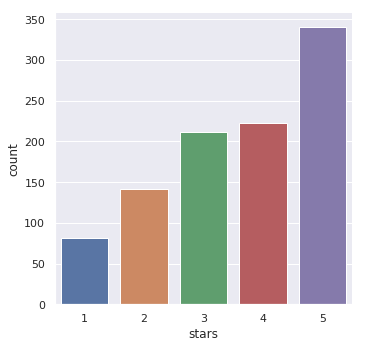

```python
# plot histogram for starts
_ = sns.catplot(x='stars',kind='count',data=df)
```

```python
# get highest name counts
df[df.stars == 5].lastname.value_counts().head()
```

```
ROBINSON    135
DANIELS       9
CALDWELL      8
JOHNSTON      6
JACOBS        6
Name: lastname, dtype: int64
```

```python
# get differences in mean stars by name
robinson_mean = df[df.lastname == 'ROBINSON'].stars.mean()
other_mean = df[df.lastname != 'ROBINSON'].stars.mean()
robinson_mean_diff = robinson_mean - other_mean
print('robinson mean stars: {}'.format(robinson_mean))
print('other mean stars   : {}'.format(other_mean))
print('difference in mean : {}'.format(robinson_mean_diff))
```

```
robinson mean stars: 4.230769230769231
other mean stars   : 3.433080808080808
difference in mean : 0.7976884226884229
```

```python
# get counts for names
n_robinson = len(df[df.lastname == 'ROBINSON'])
n_other = len(df) - n_robinson
print('n_robinson: {}'.format(n_robinson))
print('n_other   : {}'.format(n_other))
```

```
n_robinson: 208
n_other   : 792
```

```python
# do a permutation test to test for significance of difference

stars = df.stars.values
mean_diffs = []

for i in range(10000):
    perm = np.random.permutation(stars)
    mean_1 = np.sum(perm[:n_robinson] / n_robinson)
    mean_2 = np.sum(perm[n_robinson:] / n_other)
    mean_diffs.append(mean_1-mean_2)
```

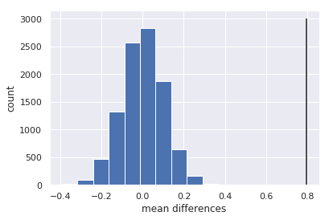

```python
_ = plt.hist(mean_diffs)
_ = plt.vlines(x=robinson_mean_diff, ymin = 0, ymax = 3000)
_ = plt.xlabel('mean differences')
_ = plt.ylabel('count')
```

```python
# calculate the p-value
p = sum(mean_diffs >= robinson_mean_diff) / len(mean_diffs)
print(p)
```

```
0.0
```

```python
# get rid of ROBINSON
df = df[df.lastname != 'ROBINSON']
```

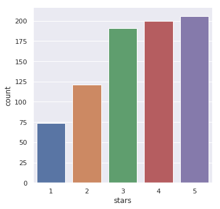

```python
_ = sns.catplot(x='stars', kind='count', data=df)
```

```python
df.info()
```

```
<class 'pandas.core.frame.DataFrame'>
Int64Index: 792 entries, 0 to 998
Data columns (total 5 columns):
lastname           792 non-null object
purchase_date      792 non-null object
stars              792 non-null int64
price              772 non-null float64
favorite_flower    792 non-null object
dtypes: float64(1), int64(1), object(3)
memory usage: 77.1+ KB
```

```python
# deal with missing prices
df.price.describe()
```

```
count    772.000000
mean      23.720669
std       11.154642
min        7.621566
25%       18.596314
50%       20.226653
75%       38.837663
max       42.996317
Name: price, dtype: float64
```

```python
df.price.fillna(df.price.mean(),inplace=True)
```

```python
df.price.describe()
```

```
count    792.000000
mean      23.720669
std       11.012720
min        7.621566
25%       18.667060
50%       20.277274
75%       38.721417
max       42.996317
Name: price, dtype: float64
```

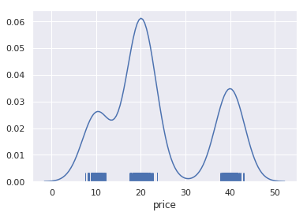

```python
_ = sns.distplot(df.price, hist=False, rug=True)
```

```python
df.info()
```

```
<class 'pandas.core.frame.DataFrame'>
Int64Index: 792 entries, 0 to 998
Data columns (total 5 columns):
lastname           792 non-null object
purchase_date      792 non-null object
stars              792 non-null int64
price              792 non-null float64
favorite_flower    792 non-null object
dtypes: float64(1), int64(1), object(3)
memory usage: 77.1+ KB
```

```python
# deal with flower
df.favorite_flower.head()
```

```
0         iris
2    carnation
4    carnation
5      gerbera
7      gerbera
Name: favorite_flower, dtype: object
```

```python
flower_dummies = pd.get_dummies(df.favorite_flower, prefix='favorite_flower')
```

```python
df = df.join(flower_dummies)
```

```python
df.head()
```

|  | lastname | purchase_date | stars | price | favorite_flower | favorite_flower_carnation | favorite_flower_daffodil | favorite_flower_daisy | favorite_flower_gardenia | favorite_flower_gerbera | favorite_flower_iris | favorite_flower_jasmine | favorite_flower_lilac | favorite_flower_orchid | favorite_flower_rose | favorite_flower_sunflower | favorite_flower_tulip |
| --- | --- | --- | --- | --- | --- | --- | --- | --- | --- | --- | --- | --- | --- | --- | --- | --- | --- |
| 0 | PERKINS | 2017-04-08 | 5 | 19.599886 | iris | 0 | 0 | 0 | 0 | 0 | 1 | 0 | 0 | 0 | 0 | 0 | 0 |
| 2 | WILLIAMSON | 2017-03-20 | 4 | 19.339138 | carnation | 1 | 0 | 0 | 0 | 0 | 0 | 0 | 0 | 0 | 0 | 0 | 0 |
| 4 | RHODES | 2017-03-24 | 1 | 22.179522 | carnation | 1 | 0 | 0 | 0 | 0 | 0 | 0 | 0 | 0 | 0 | 0 | 0 |
| 5 | NGUYEN | 2017-01-03 | 3 | 9.713733 | gerbera | 0 | 0 | 0 | 0 | 1 | 0 | 0 | 0 | 0 | 0 | 0 | 0 |
| 7 | GRAVES | 2017-02-26 | 5 | 9.912852 | gerbera | 0 | 0 | 0 | 0 | 1 | 0 | 0 | 0 | 0 | 0 | 0 | 0 |

```python
#collapse rows
g = df.groupby('lastname')
```

```python
mean_prices = g.price.mean()
mean_prices.head()
```

```
lastname
ADAMS        38.617753
ALEXANDER    30.106511
ALLEN        26.657993
ALVAREZ      20.676235
ANDERSON     14.653257
Name: price, dtype: float64
```

```python
# create new dataframe for engineered features
dfe = pd.DataFrame()
```

```python
dfe['mean_price'] = mean_prices
```

```python
dfe.head()
```

| lastname | mean_price |
| --- | --- |
| ADAMS | 38.617753 |
| ALEXANDER | 30.106511 |
| ALLEN | 26.657993 |
| ALVAREZ | 20.676235 |
| ANDERSON | 14.653257 |

```python
from scipy.stats import zscore

dfe['mean_price_normed'] = zscore(dfe.mean_price.values)
```

```python
dfe.head()
```

| lastname | mean_price | mean_price_normed |
| --- | --- | --- |
| ADAMS | 38.617753 | 1.852124 |
| ALEXANDER | 30.106511 | 0.825236 |
| ALLEN | 26.657993 | 0.409170 |
| ALVAREZ | 20.676235 | -0.312534 |
| ANDERSON | 14.653257 | -1.039211 |

```python
dfe.drop('mean_price',axis=1,inplace=True)
```

```python
g.stars.median().head()
```

```
lastname
ADAMS        2.5
ALEXANDER    4.5
ALLEN        4.0
ALVAREZ      3.0
ANDERSON     2.0
Name: stars, dtype: float64
```

```python
dfe['median_stars'] = g.stars.median()
```

```python
dfe.head()
```

| lastname | mean_price_normed | median_stars |
| --- | --- | --- |
| ADAMS | 1.852124 | 2.5 |
| ALEXANDER | 0.825236 | 4.5 |
| ALLEN | 0.409170 | 4.0 |
| ALVAREZ | -0.312534 | 3.0 |
| ANDERSON | -1.039211 | 2.0 |

```python
dfe['median_stars_normed'] = zscore(dfe.median_stars.values)
dfe.drop('median_stars',axis=1,inplace=True)
```

```python
dfe.head()
```

| lastname | mean_price_normed | median_stars_normed |
| --- | --- | --- |
| ADAMS | 1.852124 | -0.946378 |
| ALEXANDER | 0.825236 | 1.053515 |
| ALLEN | 0.409170 | 0.553542 |
| ALVAREZ | -0.312534 | -0.446405 |
| ANDERSON | -1.039211 | -1.446352 |

```python
flower_columns = [x for x in df.columns if x.startswith('favorite_flower_')]
```

```python
favorite_flowers = g[flower_columns].sum()
```

```python
# reduce from count to 0,1
dfe = dfe.join(favorite_flowers.applymap(lambda x: int(x > 0)))
```

```python
dfe.head()
```

| lastname | mean_price_normed | median_stars_normed | favorite_flower_carnation | favorite_flower_daffodil | favorite_flower_daisy | favorite_flower_gardenia | favorite_flower_gerbera | favorite_flower_iris | favorite_flower_jasmine | favorite_flower_lilac | favorite_flower_orchid | favorite_flower_rose | favorite_flower_sunflower | favorite_flower_tulip |
| --- | --- | --- | --- | --- | --- | --- | --- | --- | --- | --- | --- | --- | --- | --- |
| ADAMS | 1.852124 | -0.946378 | 0 | 0 | 0 | 0 | 0 | 0 | 0 | 0 | 1 | 0 | 0 | 0 |
| ALEXANDER | 0.825236 | 1.053515 | 0 | 0 | 0 | 0 | 0 | 0 | 0 | 0 | 0 | 0 | 1 | 0 |
| ALLEN | 0.409170 | 0.553542 | 0 | 0 | 0 | 0 | 0 | 0 | 0 | 0 | 0 | 1 | 0 | 0 |
| ALVAREZ | -0.312534 | -0.446405 | 0 | 0 | 0 | 0 | 0 | 0 | 0 | 0 | 1 | 0 | 0 | 0 |
| ANDERSON | -1.039211 | -1.446352 | 0 | 0 | 1 | 0 | 0 | 0 | 0 | 0 | 0 | 0 | 0 | 0 |

```python
# generate label for repeat customer
labels = df.lastname.value_counts().apply(lambda x: int(x > 1))
```

```python
labels.head()
```

```
DANIELS     1
JACOBS      1
BURKE       1
CALDWELL    1
HUNTER      1
Name: lastname, dtype: int64
```

```python
# set name for join
labels.name = 'reorder_label'
```

```python
dfe = dfe.join(labels)
```

```python
dfe.head()
```

| lastname | mean_price_normed | median_stars_normed | favorite_flower_carnation | favorite_flower_daffodil | favorite_flower_daisy | favorite_flower_gardenia | favorite_flower_gerbera | favorite_flower_iris | favorite_flower_jasmine | favorite_flower_lilac | favorite_flower_orchid | favorite_flower_rose | favorite_flower_sunflower | favorite_flower_tulip | reorder_label |
| --- | --- | --- | --- | --- | --- | --- | --- | --- | --- | --- | --- | --- | --- | --- | --- |
| ADAMS | 1.852124 | -0.946378 | 0 | 0 | 0 | 0 | 0 | 0 | 0 | 0 | 1 | 0 | 0 | 0 | 1 |
| ALEXANDER | 0.825236 | 1.053515 | 0 | 0 | 0 | 0 | 0 | 0 | 0 | 0 | 0 | 0 | 1 | 0 | 1 |
| ALLEN | 0.409170 | 0.553542 | 0 | 0 | 0 | 0 | 0 | 0 | 0 | 0 | 0 | 1 | 0 | 0 | 1 |
| ALVAREZ | -0.312534 | -0.446405 | 0 | 0 | 0 | 0 | 0 | 0 | 0 | 0 | 1 | 0 | 0 | 0 | 0 |
| ANDERSON | -1.039211 | -1.446352 | 0 | 0 | 1 | 0 | 0 | 0 | 0 | 0 | 0 | 0 | 0 | 0 | 1 |

```python
dfe.info()
```

```
<class 'pandas.core.frame.DataFrame'>
Index: 252 entries, ADAMS to WOODS
Data columns (total 15 columns):
mean_price_normed            252 non-null float64
median_stars_normed          252 non-null float64
favorite_flower_carnation    252 non-null int64
favorite_flower_daffodil     252 non-null int64
favorite_flower_daisy        252 non-null int64
favorite_flower_gardenia     252 non-null int64
favorite_flower_gerbera      252 non-null int64
favorite_flower_iris         252 non-null int64
favorite_flower_jasmine      252 non-null int64
favorite_flower_lilac        252 non-null int64
favorite_flower_orchid       252 non-null int64
favorite_flower_rose         252 non-null int64
favorite_flower_sunflower    252 non-null int64
favorite_flower_tulip        252 non-null int64
reorder_label                252 non-null int64
dtypes: float64(2), int64(13)
memory usage: 41.5+ KB
```

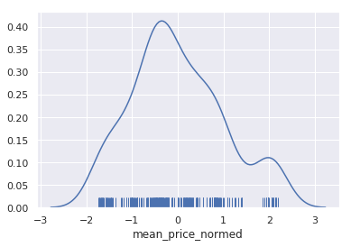

```python
_ = sns.distplot(dfe.mean_price_normed, hist=False, rug=True)
```

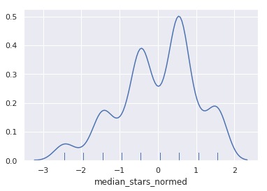

```python
_ = sns.distplot(dfe.median_stars_normed, hist=False, rug=True)
```

```python
# get data and label column names
data_cols = dfe.columns[:-1]
label_col = dfe.columns[-1]
```

```python
data_cols
```

```
Index(['mean_price_normed', 'median_stars_normed', 'favorite_flower_carnation',
       'favorite_flower_daffodil', 'favorite_flower_daisy',
       'favorite_flower_gardenia', 'favorite_flower_gerbera',
       'favorite_flower_iris', 'favorite_flower_jasmine',
       'favorite_flower_lilac', 'favorite_flower_orchid',
       'favorite_flower_rose', 'favorite_flower_sunflower',
       'favorite_flower_tulip'],
      dtype='object')
```

```python
label_col
```

```
'reorder_label'
```

```python
from sklearn.ensemble import RandomForestClassifier
from sklearn.model_selection import cross_val_score
from sklearn.model_selection import train_test_split
```

```python
# split into train and test (hold out) sets
X_train, X_test, y_train, y_test = train_test_split(dfe.loc[:,data_cols],
                                                    dfe.loc[:,label_col],
                                                    test_size=0.2,
                                                    stratify=dfe.loc[:,label_col])
print(X_train.shape)
print(y_train.shape)
print(X_test.shape)
print(y_test.shape)
```

```
(201, 14)
(201,)
(51, 14)
(51,)
```

```python
# perform cross validation to tune parameters (not done here)
rf = RandomForestClassifier()
cv_scores = cross_val_score(rf, X_train, y_train, cv=3)
print(cv_scores)
```

```
[0.77941176 0.73134328 0.66666667]
```

```python
print('mean cv accuracy: {:0.3f}'.format(np.mean(cv_scores)))
```

```
mean cv accuracy: 0.726
```

```python
# fit on training data and score on test
rf.fit(X_train,y_train)
print('test set accuracy: {:0.3f}'.format(rf.score(X_test,y_test)))
```

```
test set accuracy: 0.647
```

```python
list(zip(data_cols,rf.feature_importances_))
```

```
[('mean_price_normed', 0.617548847396738),
 ('median_stars_normed', 0.20093613359097814),
 ('favorite_flower_carnation', 0.018160623818390106),
 ('favorite_flower_daffodil', 0.014131071210514486),
 ('favorite_flower_daisy', 0.014032523893977217),
 ('favorite_flower_gardenia', 0.012776736263171842),
 ('favorite_flower_gerbera', 0.035536945584541235),
 ('favorite_flower_iris', 0.01177479747364079),
 ('favorite_flower_jasmine', 0.004704517373914542),
 ('favorite_flower_lilac', 0.014355867938106013),
 ('favorite_flower_orchid', 0.02284696278881289),
 ('favorite_flower_rose', 0.009080836132577012),
 ('favorite_flower_sunflower', 0.01037649637651292),
 ('favorite_flower_tulip', 0.01373764015812488)]
```

```python
# how well could we do just by guessing 1 for everyone?
dfe.loc[:,label_col].sum() / len(dfe)
```

```
0.7103174603174603
```

### Python Data Structures Review

## Appendix

### Questions for a Data Scientist

- What's the question we're trying to answer? (often the hardest part)
- Is this data ready to be analyzed? (data cleaning)
- Does this data look right? (visual inspection)
- How do we automatically process this data so that we can use it? (ETL + pipelining)
- Are there groups of things here? + How might we group these things? (clustering)
- How do we tell this from that? (classification)
- Can we explain and/or predict this value? (regression)
- What are the important features of my data? (feature selection)
- Can I reduce the size of my dataset? (dimensionality reduction)
- How are we going to measure whether this works or not? (model evaluation + cross validation)
- How do I find the right settings for my model? (grid search)
- Which model should I use? (model selection)
- Is there a pattern here and what is it correlated with? (correlation)
- How can I be sure what I've found is significant? (hypothesis testing)
- How do I communicate the result of this work? (reporting)
- How do I use these images? (image recognition)
- How do I use these documents? (natural language processing)
- What are these documents about? (topic modeling)
- Can I tell if these documents are positive or negative? (sentiment analysis)
- What if I know my data is time dependent? (time-series)
- Which items should we recommend? (recommendation engine)
- Can we find other things like this thing? (similarity measures)
- Which of these are the same? (deduplication)
- How do we handle all of this data? (data-bases and data-storage)
- How do I create a tool to produce results? (API)
- How do I keep up with DS, stay educated, improve my skills?